# Sustainability of Brazilian forest concessions

## 2.2 The VDDE model

In this study we used the volume dynamics with differential equations model (VDDE) (Piponiot et al. 2018). The VDDE model calculates the volume of all live trees $\geq$ 50 cm diameter at breast height (DBH), the standard minimum cutting size in the Brazilian Amazon. The portion of this volume composed of commercial species is referred to as the commercial volume.

The input variables set for each simulation are logging intensity, logging cycle length, and the initial proportion of the volume that is commercial ($\omega_0$). Low values of $\omega_0$ represent highly selective logging where only the most valuable species are harvested whereas high values mean that most species are logged. Other parameters of the VDDE model are spatially defined at a 1$^\circ$ resolution. The model was calibrated for the Amazon Basin with a Bayesian framework with data from 3500 ha of forest plots, among which 845 ha are from 15 sites monitored for as long as 30 years after selective logging (Sist et al. 2015; Piponiot et al. 2019). Predictions of commercial volume recovery rates thereby vary with location.

Each logging cycle includes the harvest itself as a function of logging intensity and forest characteristics and the post-logging volume recovery phase, which varies with logging cycle length and forest characteristics. Logging lowers both the total volume and the proportion of commercial volume, but both then increase during the recovery phase, although the proportion of commercial volume takes longer to recover because it relies solely on the recruitment of trees < 50 cm DBH (Piponiot et al. 2019). These two steps are sequentially repeated to simulate 1000 years of logging.

The results are then multiplied by the area of current or potential concessions in each 1$^\circ$ pixel, and by a factor $\pi \sim \mathcal{Beta}(8.2, 5.9)$ between 0 and 1, with a mean value of 58%. This factor $\pi$, which was calibrated with data from logging concessions in French Guiana, reflects the ratio between logged areas and the initially allocated areas, mostly because of slope restrictions and riparian reserves, but also heavy forest degradation because of illegal logging and other disturbances (Verissimo et al. 2006; Piponiot et al. 2019).

Uncertainties are propagated throughout the model by drawing all parameter values from their calibrated distribution (from Piponiot et al. 2019), and simulating logging cycles with these parameter values. This process is repeated 100 times and summary statistics (medians and 95% credibility intervals) are calculated at each time step.

## 2.3 Testing scenarios

We tested 27 different scenarios by using combinations of the following inputs: (i) initial proportion of commercial volume: 20% (highly selective), 50% (intermediate) or 90% (non-selective); (ii) logging intensity: 10 m3.ha-1 (low), 20 m$^3$.ha$^{-1}$ (intermediate) or 30 m$^3$.ha$^{-1}$ (high); (iii) cutting cycle length: 20 years (short), 35 years (intermediate) or 60 years (long). These scenarios are then applied to the current area of concessions and to the area of all potential concessions (see “Study areas”).

For each scenario we simulated 1000 years of logging cycles, and determined the duration of maintained timber production, i.e. the time before timber stocks become insufficient to maintain a constant timber production as illustrated in Fig. 2.2. This maintained production is different from sustained timber production which theoretically shows a constant timber yield and stock over time (Fig. 2.2).

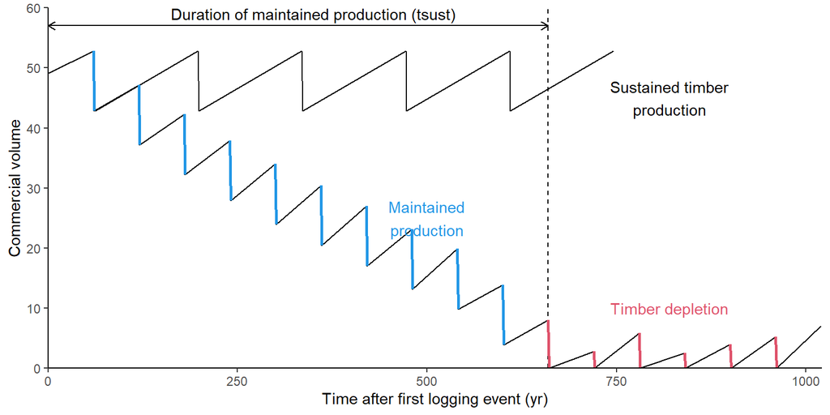

Figure 2.2: Illustration of the duration of maintained and sustained timber production. The x-axis represents years after the first selective harvest, and the y-axis represents commercial volumes as simulated by the model with a logging intensity of 10 m$^3$.ha$^{-1}$ and a logging cycle of 60 years. At each harvest, commercial volumes decrease (blue segments). If logging cycles are not long enough to allow recovery, the commercial volume decreases until it is not sufficient to maintain a constant production (10, 20 or 30 m$^3$.ha$^{-1}$, red segments). The time taken to reach this limit is the duration of the maintained production. In the sustained timber production, both timber yield and stocks remain constant.